# Full-metric benchmark of RepeatMasker on simulated genomes, complete vs. incomplete library

Ting-Hsuan Chen

05 November, 2026

Revision items 23-28 (R2#5, R3-major#6, #7, #12, R3-minor#10, #16). RepeatMasker annotations of the five scenario 1 genomes (Fig. 3D) are scored against the simulator’s ground-truth GFF with TEbenchtop (`15_tair10_benchmark_repeatmasker.sh`):

- **mode 2**: base-pair-level TP/FP/FN, recall (sensitivity), precision, F1 and FDR, overall and by TE type, and per identity x integrity slice;
- **mode 3**: per-locus overlaps with the annotation (boundaries, coverage, number of hits).

Three libraries are compared: the complete library used for simulation (`full`), and the same library with 25% or 50% of families removed at random (`drop25`, `drop50`; drop50 removes all of drop25’s families plus as many again). Removing families mimics annotating a genome whose library lacks some families, as for non-model organisms. The evaluation only needs the annotation as a GFF, so the same workflow applies to any annotation tool, including de novo pipelines.

## 1. Base-pair-level metrics (TEbenchtop mode 2)

Base-pair-level recall, precision, F1 and FDR by TE type (mean and SD of 5 replicates).

| library | type | recall_mean | recall_sd | prec_mean | prec_sd | F1_mean | F1_sd | FDR_mean | FDR_sd |
| --- | --- | --- | --- | --- | --- | --- | --- | --- | --- |
| Full library | DNA | 0.9688 | 0.0026 | 0.9991 | 0.0000 | 0.9837 | 0.0013 | 0.0009 | 0.0000 |
| 25% families removed | DNA | 0.8569 | 0.0094 | 0.9990 | 0.0001 | 0.9225 | 0.0055 | 0.0010 | 0.0001 |
| 50% families removed | DNA | 0.6347 | 0.0061 | 0.9979 | 0.0002 | 0.7759 | 0.0046 | 0.0021 | 0.0002 |
| Full library | LINE | 0.9730 | 0.0034 | 0.9988 | 0.0001 | 0.9857 | 0.0018 | 0.0012 | 0.0001 |
| 25% families removed | LINE | 0.8331 | 0.0162 | 0.9990 | 0.0000 | 0.9085 | 0.0095 | 0.0010 | 0.0000 |
| 50% families removed | LINE | 0.6370 | 0.0303 | 0.9991 | 0.0001 | 0.7777 | 0.0225 | 0.0009 | 0.0001 |
| Full library | LTR | 0.9739 | 0.0006 | 0.9989 | 0.0000 | 0.9863 | 0.0003 | 0.0011 | 0.0000 |
| 25% families removed | LTR | 0.8690 | 0.0090 | 0.9990 | 0.0000 | 0.9294 | 0.0052 | 0.0010 | 0.0000 |
| 50% families removed | LTR | 0.7742 | 0.0112 | 0.9983 | 0.0003 | 0.8720 | 0.0072 | 0.0017 | 0.0003 |
| Full library | RC | 0.9657 | 0.0044 | 0.9986 | 0.0004 | 0.9819 | 0.0024 | 0.0014 | 0.0004 |
| 25% families removed | RC | 0.7940 | 0.0649 | 0.9971 | 0.0010 | 0.8828 | 0.0404 | 0.0029 | 0.0010 |
| 50% families removed | RC | 0.4120 | 0.0627 | 0.9650 | 0.0222 | 0.5748 | 0.0585 | 0.0350 | 0.0222 |
| Full library | SINE | 0.8675 | 0.0289 | 0.9964 | 0.0001 | 0.9273 | 0.0166 | 0.0036 | 0.0001 |
| 25% families removed | SINE | 0.7404 | 0.0545 | 0.9930 | 0.0016 | 0.8474 | 0.0358 | 0.0070 | 0.0016 |
| 50% families removed | SINE | 0.6035 | 0.0771 | 0.9969 | 0.0001 | 0.7494 | 0.0617 | 0.0031 | 0.0001 |
| Full library | all | 0.9704 | 0.0011 | 0.9990 | 0.0000 | 0.9845 | 0.0006 | 0.0010 | 0.0000 |
| 25% families removed | all | 0.8552 | 0.0090 | 0.9991 | 0.0000 | 0.9215 | 0.0053 | 0.0009 | 0.0000 |
| 50% families removed | all | 0.6855 | 0.0075 | 0.9991 | 0.0000 | 0.8131 | 0.0053 | 0.0009 | 0.0000 |

Saved file name: bm_basic_metrics_summary.csv

Specificity and accuracy are not shown: true negatives are dominated by the non-TE backbone, which inflates both. They are kept in the saved table.

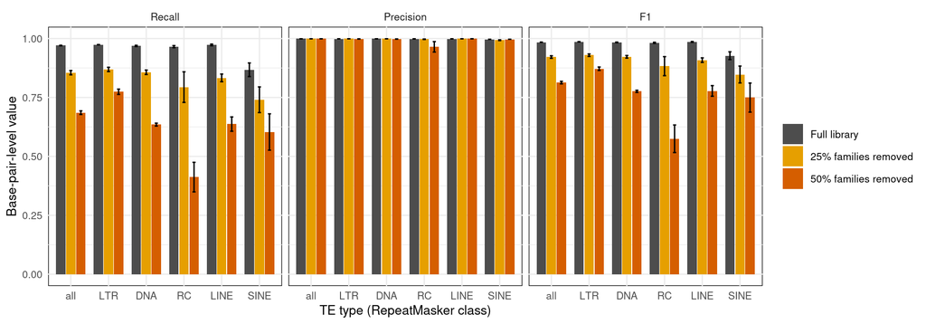

Saved file name: bm_basic_metrics.png

### 1.1 Radar charts of all metrics

All six metrics per TE type, one polygon per library (mean of 5 replicates). Specificity and accuracy are close to 1 for every library because of the large number of true-negative backbone bases.

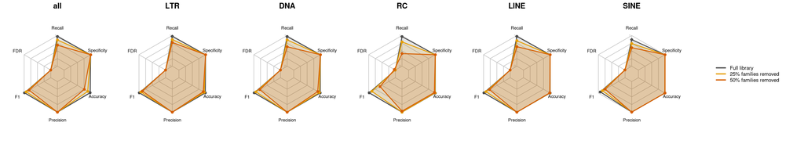

Saved file name: bm_basic_metrics_radar.png

## 2. False positives

False-positive loci are RepeatMasker hits that overlap no simulated TE. Because mode 1 inserts TEs into the TE-depleted TAIR10 genome, some of these hits may be TE remnants left in the backbone after masking rather than annotation errors; RepeatMasker on the backbone alone (full library) measures that baseline.

False-positive loci (hits overlapping no simulated TE) and false-positive bases (mean and SD of 5 replicates).

| library | fp_loci_mean | fp_loci_sd | fp_loci_bp_mean | fp_loci_bp_sd | FP_bp_mean | FP_bp_sd |
| --- | --- | --- | --- | --- | --- | --- |
| Full library | 391 | 32 | 39,953 | 4,211 | 337,777 | 13,300 |
| 25% families removed | 315 | 27 | 31,839 | 3,704 | 275,585 | 10,949 |
| 50% families removed | 207 | 20 | 23,895 | 2,443 | 207,446 | 8,481 |

```
## Backbone alone (full library): 166 RepeatMasker hits covering 32,041 bp.
```

Saved file name: bm_false_positives_summary.csv

## 3. Recall by identity and integrity (TEbenchtop mode 2 slices)

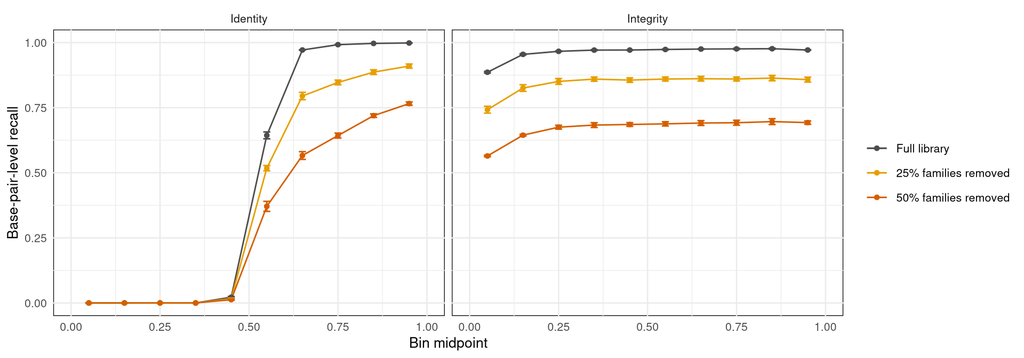

Saved file names: bm_recall_by_identity_integrity.csv, bm_recall_by_identity_integrity.png

## 4. Locus-level evaluation (TEbenchtop mode 3)

For every simulated locus, the RepeatMasker hit with the largest overlap (either strand) is used for classification; same-strand hits are used for boundaries and fragmentation.

- **Fragmentation**: number of same-strand RepeatMasker hits covering the locus (0 = missed, 1 = single hit, >= 2 = split into several hits).
- **Merging**: a RepeatMasker hit overlapping two or more simulated loci.
- **Boundary accuracy**: start/end difference (bp) between a locus and its single same-strand hit.
- **Classification**: the best hit’s family, superfamily and class compared with the simulated locus. Loci whose family was removed from the library are reported separately: they can only be annotated with a related family, or missed.

### 4.1 Fragmentation, merging and boundaries

Per-locus results (mean and SD of 5 replicates): missed, single-hit and fragmented loci; RepeatMasker hits merging >= 2 loci; boundary accuracy of single-hit loci.

| library | pct_missed_mean | pct_missed_sd | pct_single_hit_mean | pct_single_hit_sd | pct_fragmented_mean | pct_fragmented_sd | median_coverage_mean | median_coverage_sd | pct_hits_merging_mean | pct_hits_merging_sd | pct_both_ends_within_10bp_mean | pct_both_ends_within_10bp_sd | pct_both_ends_within_50bp_mean | pct_both_ends_within_50bp_sd | median_abs_start_diff_mean | median_abs_start_diff_sd | median_abs_end_diff_mean | median_abs_end_diff_sd |
| --- | --- | --- | --- | --- | --- | --- | --- | --- | --- | --- | --- | --- | --- | --- | --- | --- | --- | --- |
| Full library | 12.34 | 0.34 | 85.46 | 0.41 | 2.20 | 0.12 | 1.00 | 0.00 | 4.41 | 0.28 | 85.55 | 0.25 | 96.60 | 0.14 | 1.0 | 0.00 | 0 | 0 |
| 25% families removed | 20.88 | 0.27 | 72.12 | 0.40 | 7.01 | 0.30 | 1.00 | 0.00 | 3.51 | 0.28 | 79.36 | 0.75 | 90.55 | 0.48 | 1.0 | 0.00 | 0 | 0 |
| 50% families removed | 33.20 | 1.03 | 56.17 | 1.26 | 10.63 | 0.55 | 0.87 | 0.04 | 2.85 | 0.27 | 70.09 | 0.79 | 81.30 | 0.57 | 1.8 | 0.45 | 0 | 0 |

Saved file name: bm_locus_level_summary.csv

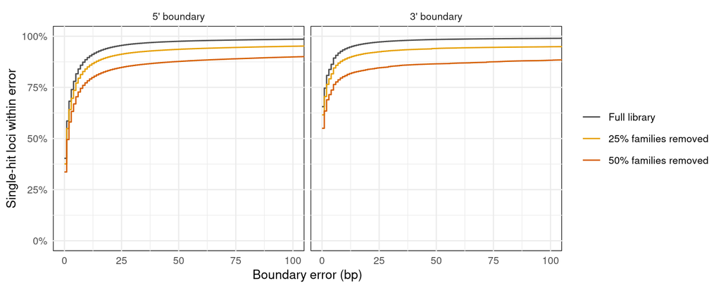

Saved file name: bm_boundary_differences.png

### 4.2 Classification

Classification of the best-overlapping RepeatMasker hit per simulated locus (% of loci; mean and SD of 5 replicates).

| library | family_status | classification | pct_mean | pct_sd |
| --- | --- | --- | --- | --- |
| Full library | family in library | same family | 87.31 | 0.36 |
| Full library | family in library | same superfamily | 0.27 | 0.03 |
| Full library | family in library | same class | 0.08 | 0.01 |
| Full library | family in library | different class | 0.36 | 0.02 |
| Full library | family in library | not detected | 11.98 | 0.33 |
| 25% families removed | family in library | same family | 87.95 | 0.16 |
| 25% families removed | family in library | same superfamily | 0.21 | 0.02 |
| 25% families removed | family in library | same class | 0.06 | 0.01 |
| 25% families removed | family in library | different class | 0.27 | 0.02 |
| 25% families removed | family in library | not detected | 11.51 | 0.17 |
| 25% families removed | family removed | same family | 0.01 | 0.00 |
| 25% families removed | family removed | same superfamily | 47.65 | 1.22 |
| 25% families removed | family removed | same class | 3.67 | 0.27 |
| 25% families removed | family removed | different class | 1.33 | 0.16 |
| 25% families removed | family removed | not detected | 47.35 | 0.96 |
| 50% families removed | family in library | same family | 88.44 | 0.28 |
| 50% families removed | family in library | same superfamily | 0.18 | 0.02 |
| 50% families removed | family in library | same class | 0.05 | 0.01 |
| 50% families removed | family in library | different class | 0.20 | 0.01 |
| 50% families removed | family in library | not detected | 11.13 | 0.29 |
| 50% families removed | family removed | same family | 0.00 | 0.00 |
| 50% families removed | family removed | same superfamily | 41.81 | 1.17 |
| 50% families removed | family removed | same class | 3.49 | 0.46 |
| 50% families removed | family removed | different class | 1.43 | 0.18 |
| 50% families removed | family removed | not detected | 53.27 | 0.94 |

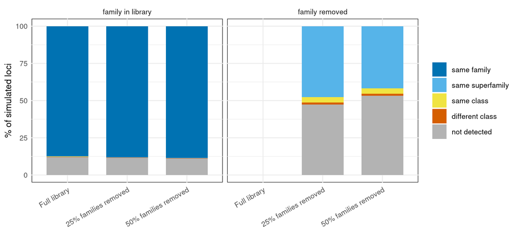

Saved file names: bm_classification_summary.csv, bm_classification.png

### 4.3 Classification by superfamily

Ribbon plots and bar plots adapted from `31.02_BM_TEtrimmer.Rmd`. Each simulated locus is counted once, using its best-overlapping hit (loci with no hit are shown as “not detected”); counts are the mean per replicate. RepeatMasker labels hits with the library’s own classification, which is the one used by the simulator, so no renaming of superfamilies is needed.

[figure not shown]

Saved file name: bm_classification_ribbon_all.png

Loci of the removed families only (drop25 and drop50): these can only be annotated with a related family, or missed.

[figure not shown]

Saved file name: bm_classification_ribbon_removed_families.png

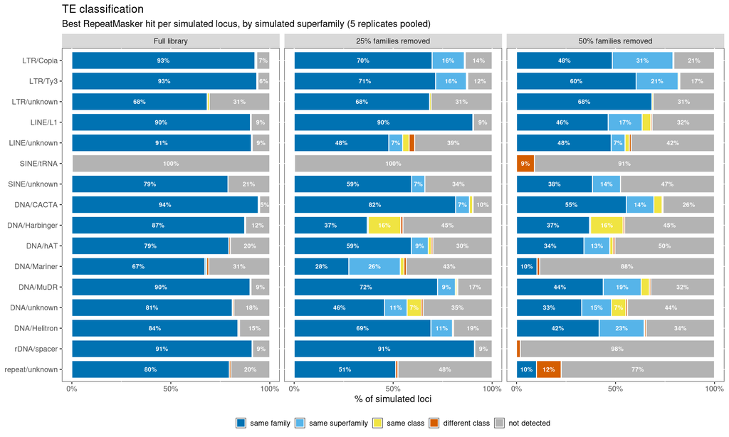

Saved file names: bm_classification_by_superfamily.csv, bm_classification_by_superfamily_barplot.csv, bm_classification_by_superfamily_barplot.png

## 5. Notes

- Nested insertions (R3-minor#16, item 28) are analysed in `24.1_item34_35_nesting_beta_sensitivity.Rmd`.
- Base-pair-level metrics do not depend on an overlap threshold; the reciprocal-overlap threshold check (item 26) is a separate analysis.
- Removed families are the same in every replicate (one fixed random order), so differences between replicates reflect the simulated genomes, not the choice of families.